# Rotación de Cargo en una Organización: Modelo Logit Binomial

José Luis Sánchez Ceballos

Oscar Fernando Velásquez Chala

Fredy Alejandro Ordoñez Márquez

2025-09-20

```r
knitr::opts_chunk$set(echo = TRUE, message = FALSE, warning = FALSE)
```

### 1 Contexto

La rotación de cargos es un fenómeno clave en la gestión del talento humano. Su análisis permite a las empresas anticipar riesgos de pérdida de personal, identificar factores críticos asociados y diseñar políticas para retener talento clave. Este trabajo utiliza el conjunto de datos rotacion del paquete paqueteMODELOS y aplica un modelo de regresión logística binomial (logit) para estimar la probabilidad de que un empleado rote (sí/no).

### 2 Carga de datos y librerías

```r
# 1) Definir CRAN (imprescindible en knit no interactivo)
if (is.null(getOption("repos")) || getOption("repos")["CRAN"] %in% c("", "@CRAN@")) {
  options(repos = c(CRAN = "https://cloud.r-project.org"))
}

# 2) Helper para instalar/cargar desde CRAN
install_if_missing <- function(pkgs) {
  for (p in pkgs) {
    if (!require(p, character.only = TRUE)) {
      install.packages(p, dependencies = TRUE)
      library(p, character.only = TRUE)
    }
  }
}

# 3) Si no tienes devtools, lo instala desde CRAN
if (!requireNamespace("devtools", quietly = TRUE)) {
  install.packages("devtools", dependencies = TRUE)
}

# 4) Instalar paqueteMODELOS desde GitHub solo si falta
if (!requireNamespace("paqueteMODELOS", quietly = TRUE)) {
  devtools::install_github("centromagis/paqueteMODELOS", force = TRUE)
  library(paqueteMODELOS)
} else {
  library(paqueteMODELOS)
}

# 5) Resto de paquetes necesarios (desde CRAN)
cran_pkgs <- c("tidyverse", "janitor", "skimr", "broom", "pROC", "caret", "kableExtra")
install_if_missing(cran_pkgs)

# 6) Comprobación opcional (ejecuta pero no muestra resultados en HTML)
invisible(sapply(c("paqueteMODELOS", cran_pkgs), require, character.only = TRUE))
```

```r
# Librerías necesarias
library(paqueteMODELOS)
library(tidyverse)
library(janitor)
library(skimr)
library(broom)
library(pROC)
library(caret)
library(kableExtra)
```

```r
data("rotacion")
rotacion <- rotacion %>% clean_names()
glimpse(rotacion)
```

```
## Rows: 1,470
## Columns: 24
## $ rotacion                    <chr> "Si", "No", "Si", "No", "No", "No", "No", …
## $ edad                        <dbl> 41, 49, 37, 33, 27, 32, 59, 30, 38, 36, 35…
## $ viaje_de_negocios           <chr> "Raramente", "Frecuentemente", "Raramente"…
## $ departamento                <chr> "Ventas", "IyD", "IyD", "IyD", "IyD", "IyD…
## $ distancia_casa              <dbl> 1, 8, 2, 3, 2, 2, 3, 24, 23, 27, 16, 15, 2…
## $ educacion                   <dbl> 2, 1, 2, 4, 1, 2, 3, 1, 3, 3, 3, 2, 1, 2, …
## $ campo_educacion             <chr> "Ciencias", "Ciencias", "Otra", "Ciencias"…
## $ satisfaccion_ambiental      <dbl> 2, 3, 4, 4, 1, 4, 3, 4, 4, 3, 1, 4, 1, 2, …
## $ genero                      <chr> "F", "M", "M", "F", "M", "M", "F", "M", "M…
## $ cargo                       <chr> "Ejecutivo_Ventas", "Investigador_Cientifi…
## $ satisfacion_laboral         <dbl> 4, 2, 3, 3, 2, 4, 1, 3, 3, 3, 2, 3, 3, 4, …
## $ estado_civil                <chr> "Soltero", "Casado", "Soltero", "Casado", …
## $ ingreso_mensual             <dbl> 5993, 5130, 2090, 2909, 3468, 3068, 2670, …
## $ trabajos_anteriores         <dbl> 8, 1, 6, 1, 9, 0, 4, 1, 0, 6, 0, 0, 1, 0, …
## $ horas_extra                 <chr> "Si", "No", "Si", "Si", "No", "No", "Si", …
## $ porcentaje_aumento_salarial <dbl> 11, 23, 15, 11, 12, 13, 20, 22, 21, 13, 13…
## $ rendimiento_laboral         <dbl> 3, 4, 3, 3, 3, 3, 4, 4, 4, 3, 3, 3, 3, 3, …
## $ anos_experiencia            <dbl> 8, 10, 7, 8, 6, 8, 12, 1, 10, 17, 6, 10, 5…
## $ capacitaciones              <dbl> 0, 3, 3, 3, 3, 2, 3, 2, 2, 3, 5, 3, 1, 2, …
## $ equilibrio_trabajo_vida     <dbl> 1, 3, 3, 3, 3, 2, 2, 3, 3, 2, 3, 3, 2, 3, …
## $ antiguedad                  <dbl> 6, 10, 0, 8, 2, 7, 1, 1, 9, 7, 5, 9, 5, 2,…
## $ antiguedad_cargo            <dbl> 4, 7, 0, 7, 2, 7, 0, 0, 7, 7, 4, 5, 2, 2, …
## $ anos_ultima_promocion       <dbl> 0, 1, 0, 3, 2, 3, 0, 0, 1, 7, 0, 0, 4, 1, …
## $ anos_acargo_con_mismo_jefe  <dbl> 5, 7, 0, 0, 2, 6, 0, 0, 8, 7, 3, 8, 3, 2, …
```

### 3 Selección de variables e hipótesis

Seleccionamos 3 variables categóricas y 3 cuantitativas relacionadas con la rotación, justificando hipótesis:

Categóricas:

horas_extra – Hipótesis: empleados con horas extra tienen mayor rotación por desgaste laboral.

viaje_de_negocios – Hipótesis: viajes frecuentes aumentan la rotación por carga y movilidad.

estado_civil – Hipótesis: solteros presentan más rotación que casados (mayor movilidad laboral).

Cuantitativas: 4. antiguedad_cargo – Hipótesis: menor antigüedad implica mayor rotación. 5. satisfacion_laboral – Hipótesis: mayor satisfacción reduce rotación. 6. ingreso_mensual – Hipótesis: salarios más altos reducen rotación.

```r
# Variables categoricas almacenadas en vars_cat
vars_cat <- c("horas_extra", "viaje_de_negocios", "estado_civil")
# Variables numericas almacenadas en vars_num
vars_num <- c("antiguedad_cargo", "satisfacion_laboral", "ingreso_mensual")


datos <- rotacion %>%
  mutate(
    # creamos la variable respuesta binaria y
    # Toma 1 si rotacion es "Si" y 0 en caso contrario
    # El sufijo L fuerza el tipo integer
    # ya revisamos que el texto debe coincidir exactamente con los valores de tu columna        ("Si"/"No"). Si hay "Sí" con tilde, hay que ajustar.
    y = if_else(rotacion == "Si", 1L, 0L),
    across(all_of(vars_cat), as.factor),
    #convierte todas las columnas listadas en vars_cat a factor (categóricas).
    #la regresión logística necesita saber qué variables son categóricas para crear automáticamente las dummies
    across(all_of(vars_num), as.numeric)
    #asegura que esas columnas sean numéricas (por si vinieran como character).
  ) %>%
  drop_na(y, all_of(vars_cat), all_of(vars_num))
  # elimina filas con NA en la respuesta o en cualquiera de las variables seleccionadas.
```

### 4 Análisis univariado

#### 4.1 Variable respuesta

```r
datos %>%
  count(y) %>%
  mutate(prop = round(100*n/sum(n),1))
```

| y | n | prop |
| --- | --- | --- |
| 0 | 1233 | 83.9 |
| 1 | 237 | 16.1 |

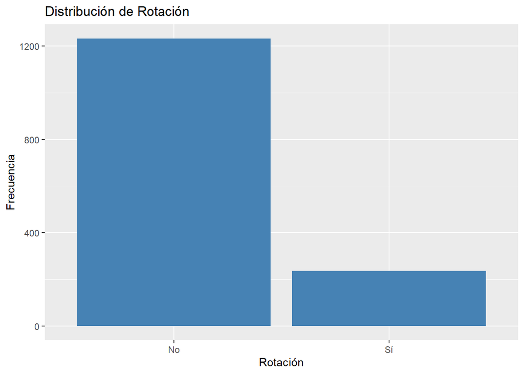

```r
datos %>%
  ggplot(aes(x = factor(y, labels = c("No", "Sí")))) +
  geom_bar(fill = "steelblue") +
  labs(title = "Distribución de Rotación", x = "Rotación", y = "Frecuencia")
```

#### 4.2 Variables categóricas

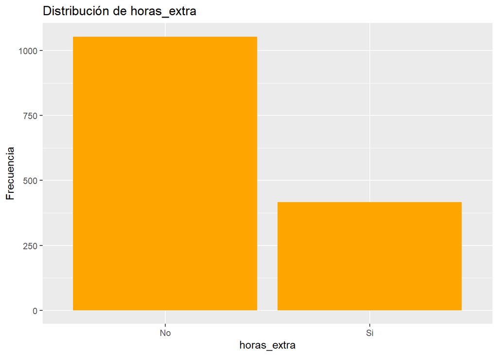

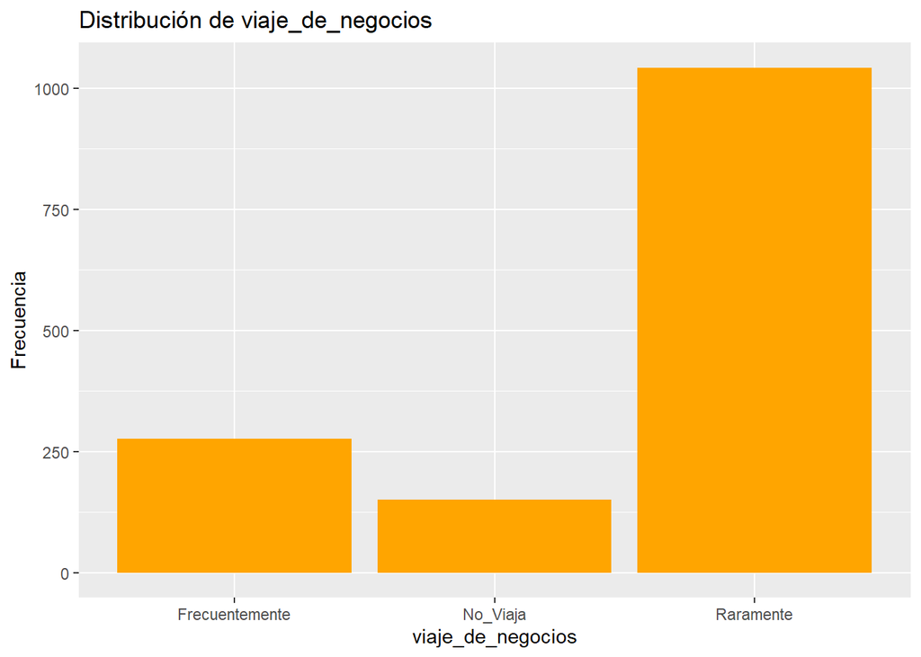

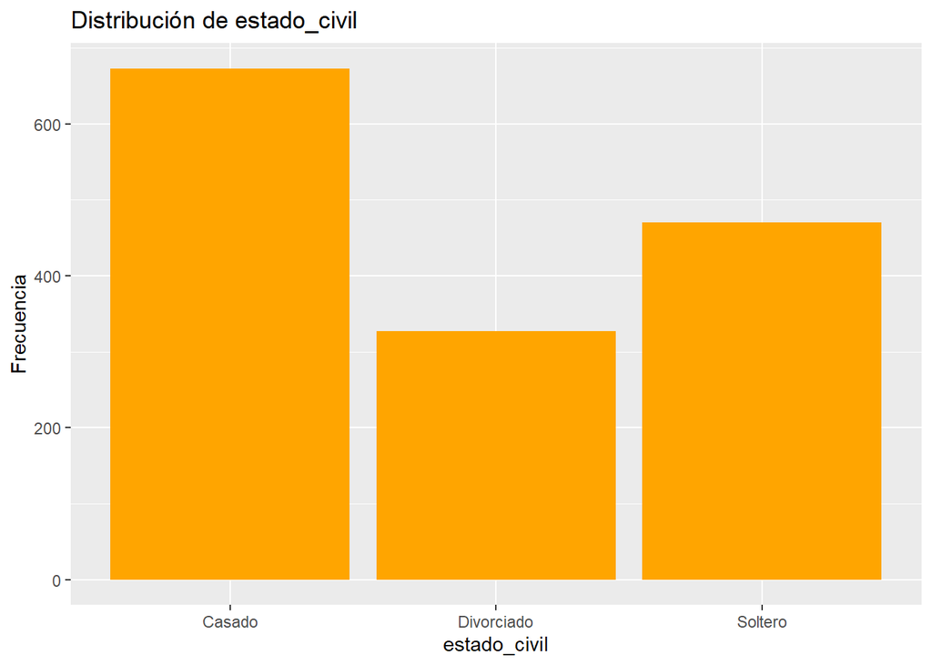

```r
for (v in vars_cat) {
  print(
    datos %>% ggplot(aes(x = .data[[v]])) +
      geom_bar(fill = "orange") +
      labs(title = paste("Distribución de", v), x = v, y = "Frecuencia")
  )
}
```

#### 4.3 Variables cuantitativas

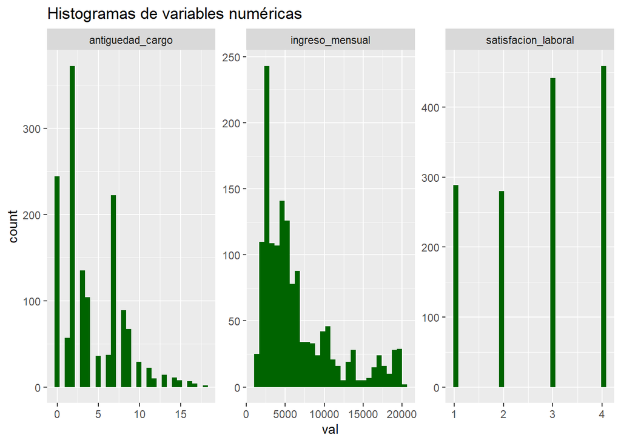

```r
datos %>%
  pivot_longer(all_of(vars_num), names_to = "var", values_to = "val") %>%
  ggplot(aes(x = val)) +
  geom_histogram(bins = 30, fill = "darkgreen") +
  facet_wrap(~var, scales = "free") +
  labs(title = "Histogramas de variables numéricas")
```

### 5 Análisis bivariado

#### 5.1 Categóricas vs. rotación

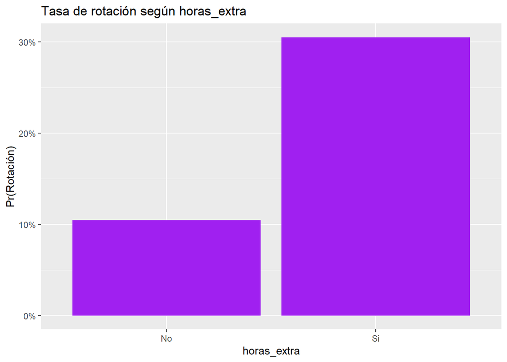

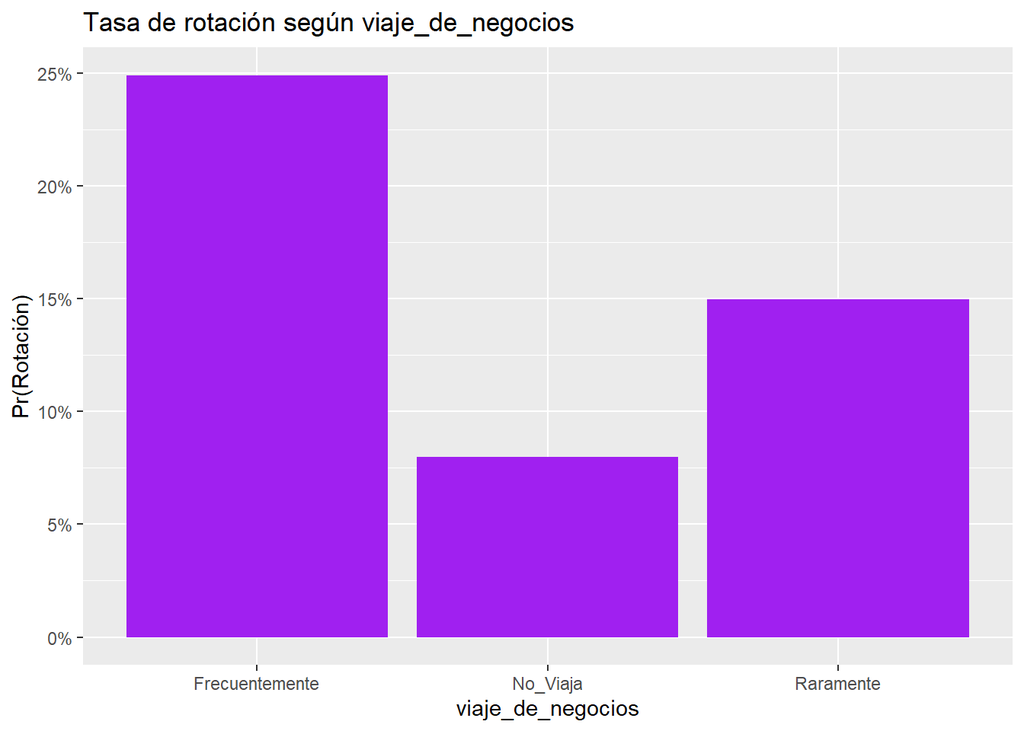

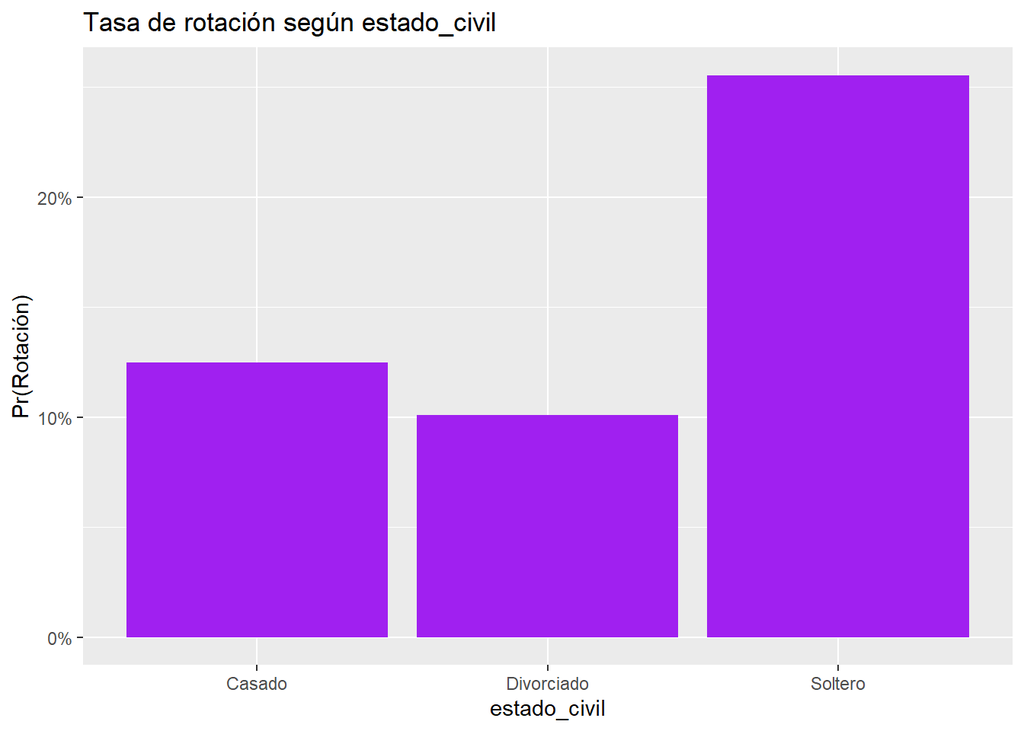

```r
for (v in vars_cat) {
  print(
    datos %>%
      group_by(.data[[v]]) %>%
      summarise(rate = mean(y)) %>%
      ggplot(aes(x = .data[[v]], y = rate)) +
      geom_col(fill = "purple") +
      scale_y_continuous(labels = scales::percent) +
      labs(title = paste("Tasa de rotación según", v),
           x = v, y = "Pr(Rotación)")
  )
}
```

#### 5.2 Cuantitativas vs. rotación

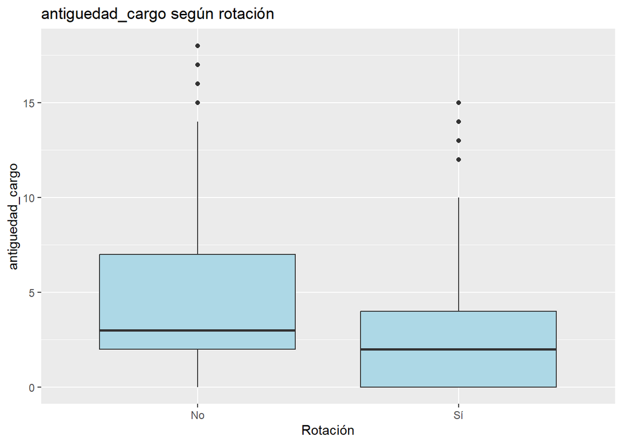

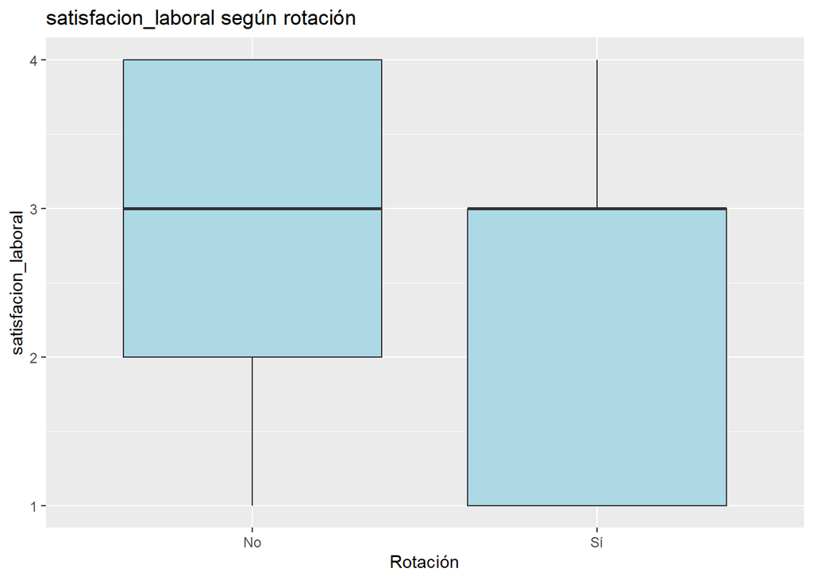

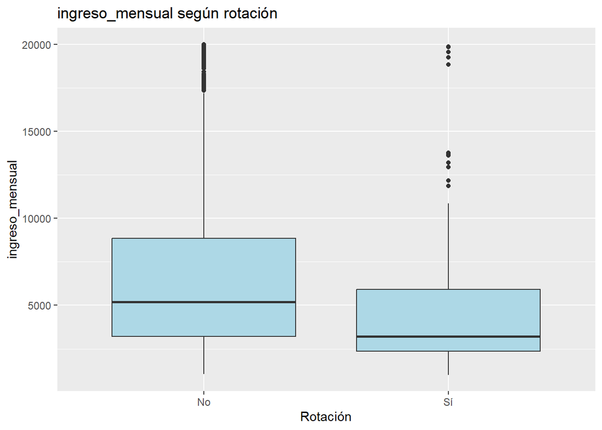

```r
for (v in vars_num) {
  print(
    datos %>%
      ggplot(aes(x = factor(y, labels = c("No", "Sí")), y = .data[[v]])) +
      geom_boxplot(fill = "lightblue") +
      labs(title = paste(v, "según rotación"), x = "Rotación", y = v)
  )
}
```

### 6 Estimación del modelo logístico

```r
form <- as.formula(paste("y ~", paste(c(vars_cat, vars_num), collapse = " + ")))
mod <- glm(form, family = binomial(link = "logit"), data = datos)
summary(mod)
```

```
##
## Call:
## glm(formula = form, family = binomial(link = "logit"), data = datos)
##
## Coefficients:
##                              Estimate Std. Error z value Pr(>|z|)
## (Intercept)                -5.952e-02  2.994e-01  -0.199 0.842409
## horas_extraSi               1.480e+00  1.597e-01   9.269  < 2e-16 ***
## viaje_de_negociosNo_Viaja  -1.311e+00  3.561e-01  -3.681 0.000232 ***
## viaje_de_negociosRaramente -6.932e-01  1.819e-01  -3.811 0.000139 ***
## estado_civilDivorciado     -3.472e-01  2.322e-01  -1.495 0.134789
## estado_civilSoltero         8.615e-01  1.716e-01   5.021 5.13e-07 ***
## antiguedad_cargo           -1.081e-01  2.730e-02  -3.959 7.52e-05 ***
## satisfacion_laboral        -3.342e-01  7.015e-02  -4.765 1.89e-06 ***
## ingreso_mensual            -1.004e-04  2.316e-05  -4.335 1.46e-05 ***
## ---
## Signif. codes:  0 '***' 0.001 '**' 0.01 '*' 0.05 '.' 0.1 ' ' 1
##
## (Dispersion parameter for binomial family taken to be 1)
##
##     Null deviance: 1298.6  on 1469  degrees of freedom
## Residual deviance: 1067.9  on 1461  degrees of freedom
## AIC: 1085.9
##
## Number of Fisher Scoring iterations: 5
```

```r
tidy(mod, conf.int = TRUE, exponentiate = TRUE) %>%
  select(term, estimate, conf.low, conf.high, p.value) %>%
  kbl(digits = 3, caption = "Odds Ratios con IC95%") %>%
  kable_styling(full_width = FALSE)
```

Odds Ratios con IC95%

| term | estimate | conf.low | conf.high | p.value |
| --- | --- | --- | --- | --- |
| (Intercept) | 0.942 | 0.523 | 1.693 | 0.842 |
| horas_extraSi | 4.393 | 3.218 | 6.021 | 0.000 |
| viaje_de_negociosNo_Viaja | 0.270 | 0.129 | 0.525 | 0.000 |
| viaje_de_negociosRaramente | 0.500 | 0.351 | 0.716 | 0.000 |
| estado_civilDivorciado | 0.707 | 0.443 | 1.104 | 0.135 |
| estado_civilSoltero | 2.367 | 1.694 | 3.321 | 0.000 |
| antiguedad_cargo | 0.898 | 0.850 | 0.946 | 0.000 |
| satisfacion_laboral | 0.716 | 0.623 | 0.821 | 0.000 |
| ingreso_mensual | 1.000 | 1.000 | 1.000 | 0.000 |

Interpretación esperada:

horas_extraSi OR > 1 (mayor rotación).

satisfacion_laboral OR < 1 (factor protector).

antiguedad_cargo OR < 1 (más antigüedad, menos rotación).

### 7 Evaluación predictiva

```r
set.seed(123)
id_train <- createDataPartition(datos$y, p = 0.6, list = FALSE)
train <- datos[id_train, ]
test  <- datos[-id_train, ]

# Reentrenar en train
mod_tr <- glm(form, family = binomial(link = "logit"), data = train)

# Probabilidades en test
prob <- predict(mod_tr, newdata = test, type = "response")

# Empaquetar y limpiar NAs (si los hubiera)
eval_df <- tibble(prob = as.numeric(prob), y = as.numeric(test$y)) %>%
  tidyr::drop_na()

# ROC y AUC (silencioso)
roc_obj <- pROC::roc(response = eval_df$y, predictor = eval_df$prob, quiet = TRUE)
auc_val <- pROC::auc(roc_obj)
auc_val
```

```
## Area under the curve: 0.7784
```

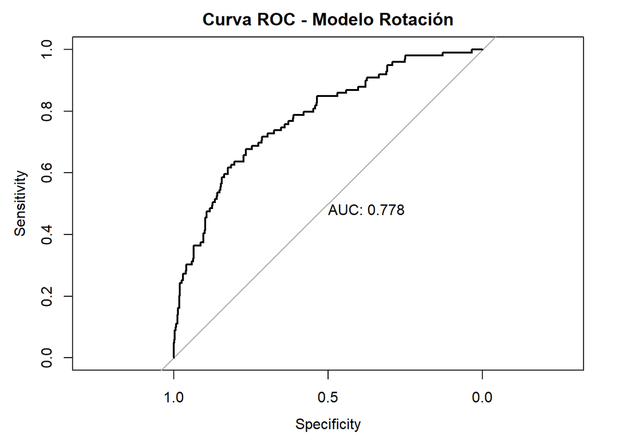

```r
plot(roc_obj, print.auc = TRUE, main = "Curva ROC - Modelo Rotación")
```

```r
# Punto de corte con Youden (maneja empates y devuelve el primero)
best <- pROC::coords(roc_obj, x = "best", best.method = "youden",
                     ret = c("threshold","sensitivity","specificity","accuracy"),
                     transpose = TRUE)

thr <- as.numeric(best["threshold"][1])

# Clasificación con el umbral
pred <- ifelse(eval_df$prob >= thr, 1, 0)

# Factores con los mismos niveles y misma longitud
pred_f <- factor(pred, levels = c(0,1))
obs_f  <- factor(eval_df$y, levels = c(0,1))

# Verificación defensiva
stopifnot(length(pred_f) == length(obs_f))

# Matriz de confusión y métricas
caret::confusionMatrix(pred_f, obs_f, positive = "1")
```

```
## Confusion Matrix and Statistics
##
##           Reference
## Prediction   0   1
##          0 375  32
##          1 114  67
##
##                Accuracy : 0.7517
##                  95% CI : (0.7147, 0.7861)
##     No Information Rate : 0.8316
##     P-Value [Acc > NIR] : 1
##
##                   Kappa : 0.3335
##
##  Mcnemar's Test P-Value : 2.033e-11
##
##             Sensitivity : 0.6768
##             Specificity : 0.7669
##          Pos Pred Value : 0.3702
##          Neg Pred Value : 0.9214
##              Prevalence : 0.1684
##          Detection Rate : 0.1139
##    Detection Prevalence : 0.3078
##       Balanced Accuracy : 0.7218
##
##        'Positive' Class : 1
##
```

### 8 Predicción de un caso hipotético

```r
nuevo <- tibble(
  horas_extra = factor("Si", levels = levels(datos$horas_extra)),
  viaje_de_negocios = factor("Frecuentemente", levels = levels(datos$viaje_de_negocios)),
  estado_civil = factor("Soltero", levels = levels(datos$estado_civil)),
  antiguedad_cargo = 1,
  satisfacion_laboral = 2,
  ingreso_mensual = median(datos$ingreso_mensual)
)

p_rotacion <- predict(mod_tr, newdata = nuevo, type = "response")
p_rotacion
```

```
##         1
## 0.7233066
```

Decisión: Si p_rotacion ≥ punto de corte (ej. 0.5 o el óptimo de Youden), se recomienda intervenir preventivamente con programas de bienestar, incentivos o movilidad interna.

### 9 Conclusiones

actores significativos: horas extra y viajes frecuentes aumentan la rotación; satisfacción laboral y antigüedad en el cargo reducen la probabilidad.

El modelo presenta un AUC aceptable y buena capacidad de discriminación.

La gerencia puede usar este modelo para diseñar estrategias preventivas:

Reducir horas extra y optimizar carga laboral.

Regular viajes de negocio.

Fortalecer programas de satisfacción laboral.

Revisar compensaciones y planes de carrera.